# Funktionen schreiben

Sophie C. Schmidt

28 08 2020

# Funktionen schreiben (falls noch Zeit ist)

Wir haben jetzt schon Funktionen angewandt und an ein-zwei Stellen wurden Funktionen extra definiert (die getmode-Funktion und in dem Giraffen-Tutorial).

Die Syntax dafür ist immer gleich:

```
myfunction <- function(x) {
das wird mit x passieren
}
```

Die neue Funktion heißt “myfunction”, sie wird auf eine Variable x angewandt und was mit x passiert, wird in den geschweiften Klammern definiert. x ist dabei der Platzhalter für das Objekt, dass der Nutzer dann in die Funktion hineingeben wird.

Stellen wir uns vor, ich möchte eine Funktion für die Berechnung des doppelten Mittelwertes von Vektoren. Die könnte z. B. so aussehen:

```r
zwei_m <- function(x){
  2*sum(x)/length(x)
  }
```

Ich rechne zwei mal die Summe von x (d.h. x muss ein Vektor sein) und teile dies durch die Länge des Vektors (Anzahl der Einträge). Ich nenne die Funktion zwei_m.

zwei_m kann ich jetzt anwenden:

```r
library(palmerpenguins)
data(penguins)

zwei_m(penguins$body_mass_g)
```

```
## [1] NA
```

Tja. Doof, ne. Das Problem kennen wir ja schon. Im Datensatz sind NA-Werte, aber die Funktion hat noch keine Möglichkeit damit umzugehen.

Erweitern wir sie also!

```r
zwei_m <- function(x){
  x <- na.omit(x)  # entferne aus x alle NA und überschreibe x damit ("Überschreibung" passiert nur innerhalb der Formel)
  2*sum(x)/length(x)
  }
```

Testen wir es also:

```r
zwei_m(penguins$body_mass_g)
```

```
## [1] 8403.509
```

Yay! In der Funktion habe ich definiert, dass das, was ich eingebe, erst durch die Funktion `na.omit()` geschickt wird und sich dabei selbst überschreibt. Damit wird dann weitergerechnet und - taadaaaaa - es gibt kein Problem mehr!

Ich kann also in der Definition einer Funktion, andere Funktionen aufrufen und mehrere Berechnungen “hintereinanderschalten”.

Es heißt, wenn man eine Abfolge von Berechnungen mehr als 3mal benutzt, sollte man sie in eine Funktion packen, damit man den Code nicht immer kopieren und einfügen muss. Außerdem kann man so Fehler vermeiden, weil man nur noch die Funktion aufrufen muss und nicht mehr den ganzen Code wiederholen.

Häufig braucht man dafür Möglichkeiten so etwas zu sagen “für jeden dieser Werte, mach das”. Oder “wenn das dabei rauskomm, dann mach was anderes als wenn dieses dabei herauskommt”. Das eröffnet das Thema der **Schleifen**.

## Schleifen

Grundsätzlich lassen sich drei Formen von Schleifen unterscheiden:

- die for-Schleife
- die while-Schleife
- die repeat (oder do-while) -Schleife

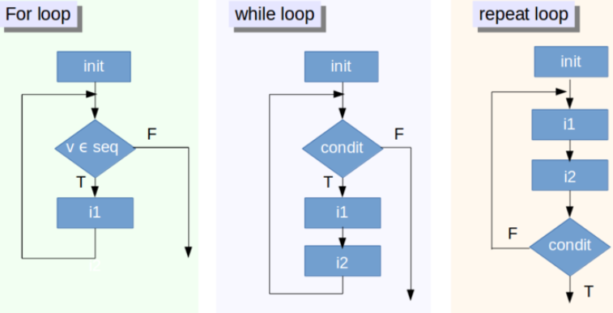

In die muss man sich jeweils etwas eindenken, aber so sehr komplex sind sie auch wieder nicht.

### Die for-Schleife

Sinn und Zweck der for-Schleife ist es, einen Code x mal auszuführen. Die Variable x ist hierbei eine ganze Zahl (*integer*) oder jeder Wert innerhalb eines Vektors. Das kann zum Beispiel so aussehen:

```r
x <- 5
for(i in 0:x) {
   print(i);
}
```

```
## [1] 0
## [1] 1
## [1] 2
## [1] 3
## [1] 4
## [1] 5
```

`for i in ...` ist dabei der Bereich, der sagt: für jedes Element i in … (oben dem Bereich 0 bis x, also 5) mache bitte das folgende { in geschweiften Klammern, hier: einfach nur “print”, d.h. drucke aus}.

Stelle ich mir vor, ich habe einen Vektor mit Worten darin, kann ich dies auch so machen:

```r
x <- c("Mein", "Pinguin", "ist", "niedlich")
for(i in x) {
   print(i);
}
```

```
## [1] "Mein"
## [1] "Pinguin"
## [1] "ist"
## [1] "niedlich"
```

### Die while-Schleife

Die while-Schleife dienst grundsätzlich dazu, einen Code so lange auszuführen, wie eine bestimmte Bedingung erfüllt ist. Das kann z. B. so aussehen:

```r
i <- 0

while (i < 5) {
   i <- i+1;
   print(i);
}
```

```
## [1] 1
## [1] 2
## [1] 3
## [1] 4
## [1] 5
```

Was passiert?

Solange i kleiner als 5 ist, wird: i + 1 gerechnet und damit i überschrieben und gedruckt.

Hier muss ich also immer eine Veränderung in der Schleife haben, die dazu führt, dass die “while”-Bedingung irgendwann erreicht ist, sonst läuft sie unendlich weiter…

Wie man merkt, wird dabei die “Entscheidung”, ob es weitergeht, immer erst “oben” in der Funktion getroffen. D.h. während die Funktion im Kreislauf läuft, wird bis zum Ende alles ausgeführt, wenn oben der “while”-Befehl noch nicht erfüllt war. Deshalb wird i hier auch bis 5 gedruckt, denn im Kopf steht “solange i kleiner ist als 5 addiere eins hinzu und druck es aus”. Man nennt das “Kopf-gesteuert”.

Unter bestimmten Umständen kann es sinnvoll sein, am Schleifenfuß die Bedingung zu prüfen, unter der die Schleife ausgeführt wird. Diese Anforderung erfüllt die

### repeat-Schleife (do while-Schleife)

Die Syntax lautet:

```r
i <- 0
repeat {
   i = i+1;
   if(i == 5) break;
   print(i)
}
```

```
## [1] 1
## [1] 2
## [1] 3
## [1] 4
```

Also, wiederhole (repeat) das addieren von 1 und drucken von i, aber wenn i == 5, dann unterbrich den Vorgang (break).

Damit haben wir eigentlich schon die nächste Möglichkeit der Steuerung von automatischen Prozessen kennengelernt: Die Bedingung.

### Bedingungen

Normalerweise wird ein R-Code Zeile für Zeile, von oben nach unten, ausgeführt. Manchmal möchte man aber eine Zeile - oder einen ganzen Block von Zeilen - nur unter einer bestimmten Bedingung durchführen. Dazu bietet sich in R die If-Anweisung an.

Dabei gilt immer if / falls (die Bedingung in der Runden Klammer wahr ist) {dann mach das in der geschweiften Klammer}:

```r
d <- 100
  if (d >= 90) {
    print(paste("Sehr gut.", d , "ist größer als 90"))
    }
```

```
## [1] "Sehr gut. 100 ist größer als 90"
```

Also, wenn d größer 90 ist, dann drucke diesen zusammengefügten Satz (Funktion paste setzt einen string aus mehreren Teilen zusammen) “sehr gut”, der Wert d, “ist größer als 90”.

Ihr könnt ja mal ausprobieren, das d auf 85 zu setzen. Was passiert dann?

Richtig. Gar nichts.

Sehr häufig möchte man aber, dass dann etwas anderes bestimmtes passiert.

Dafür gibt es “else if”

```r
  punkte <- 85
  if (punkte >= 90) {
    print(paste("Sehr gut.", d , "ist größer als 90"))
    } else if (punkte >= 80 & punkte < 90) {
    print("Gut");
    } else {
      print(paste("Nicht genügend.", d , "ist zu klein"));
  }
```

```
## [1] "Gut"
```

Also: Wenn (if) die Variable `punkte` größer als 90 ist, drucke “Sehr gut”

falls dem nicht so ist (else if) und die Variable Punkte liegt zwischen 80 und 90, drucke “Gut”

und falls keine dieser Bedingungen erfüllt ist (else), drucke “nicht genügend. der Wert ist zu klein”.

Immer wird die Bedingung dabei in runde Klammern gesetzt und die Aktion in geschweifte.

Was macht der folgende Code?

```r
x <- c(1,3,8)

if (mean(x) > 3) {
  print(mean(x))
} else {
  print("Der Mittelwert liegt unter 4")
}
```

**Aufgabe:** Diskutiert im Team:

1. Was macht der Code?
2. Was sollte gedruckt werden?
3. Was muss angepasst werden, dass auch Mittelwerte größer 2 angezeigt werden?

## Übungsaufgabe

#### 1. Übung: Welcher Mittelwert ist größer?

Programmiert gemeinsam mit eurer Gruppe eine Funktion, in der von zwei Vektoren die Mittelwerte genommen werden und dann der größere der beiden Mittelwerte ausgegeben wird.

Ihr benötigt 1. Das Berechnen der beiden Mittelwerte 2. Der Vergleich, welcher der beiden Mittelwerte größer ist 3. Den print-Befehl (Hinweis: Das Ergebnis einer Funktion kann man darin auch unterbringen)

4. zwei kleine Mini-Vektoren zum Testen.

Viel Erfolg!

### Beispiel

Stellen wir uns vor, wir wollen shapiro-wilk für das Gewicht aller drei Spezies Pinguine rechnen. Das sind drei Funktionen, kann ich da eine daraus machen? Und mir gemeinsam ausgeben lassen, welche Irrtumswahrscheinlichkeit bei jedem Test herauskommt?

Jetzt ist es die Kunst des Programmierens, sich genau zu überlegen, welche Schritte man dafür benötigt.

1. Die Funktion braucht als Eingabe etwas, das den Datensatz in seine Gruppen splittet und die Funktion braucht als Eingabe die zu testende Variable.
2. Ich brauche die einzelnen Werte für die zu splittende Variable
3. Ich muss die Gruppen anhand dieser Werte erstellen (subset)
4. den Test pro Gruppe berechnen
5. Ich muss die Teststatistik auslesen
6. Ich muss dies in einer hübschen Tabelle ablegen.
7. Die Tabelle mus ausgegeben werden.

```r
# 1. Eingabeparameter definieren

sw_nachgruppe <- function(df, gruppe, variable){

# 2. die verschiedenen Werte des gruppiernden Merkmals abgreifen

  level <- levels(as.factor(df[[gruppe]])) # levels zeigt, welche Werte in einem Faktor-Vektor vorkommen (mit as.factor sicherstellen, dass es nicht aus Versehen ein Character-Vektor ist)

  # (5.) Vorbereiten der Tabelle muss vor der Schleife passieren
  df_p <- data.frame(gruppe = character(length(level)),
                       pWert = double(length(level)))
   # erstelle die Spalte gruppe als character-Spalte mit so vielen Zeilen, wie der Vektor "level" Einträge hat (length)

# Vobrereiten eines "Zählers" für 5.
   z <- 0

# Schleife für Gruppenbildung und Berechnung:
  for (i in level) { # für jeden der Werte in level

#3. Gruppenbildung
  s <- subset(df, df[[gruppe]] == i) # filtere den Datensatz
  w <- s[[variable]] # weise die relevante Wertereihe einem Vektor zu

#4. Berechnung
  y <- shapiro.test(w) # berechne den Shapiro-Test auf die Variable

#5. + 6. Teststatistik auslesen und in Tabelle ablegen
     z <- z+1 # "hochzählen", um die richtigen Zeilen des Ausgabe-Datensatzes anzuwählen

    df_p$gruppe[z] <- i
    df_p$pWert[z] <- y$p.value
  }
  # Schleife zuende

 #7. Gesamtdatensatz ausgeben
  print(df_p)
}
# Funktion zuende
```

Testen der Funktion:

```r
library(yarrr)
data("pirates")

sw_nachgruppe(pirates, gruppe = "sex", variable = "weight")
```

```
##   gruppe     pWert
## 1 female 0.2341133
## 2   male 0.4111812
## 3  other 0.2840506
```

Und hier merkt ihr sicherlich schon etwas: Wenn ich nicht weiß, was ich in eine Funktion eingeben muss, dann kann ich damit nicht arbeiten. Für diese Variable müssen die Spaltennamen des Datensatzes pirates, nach denen die Gruppen eingeteilt werden sollen (gruppe) und der Spaltenname für die Variable, deren Normalverteilung berechnet werden soll (variable) in Hochkommas geschrieben werden.

Geht den Code der Funktion Schritt für Schritt durch. Versteht ihr, was passiert?

Fast alle Schritte haben wir während des Kurses schon einmal gemacht.

Probieren wir das doch einmal aus mit dem Pinguindatensatz, ob das Gewicht nach Spezies normalverteilt ist.